# Human v Chimp mRNA Protein Analysis

Sammi Huang

2025-01-11

### 1. Plot mean values of chimp mRNA vs human mRNA and and chimp protein expression levels vs human protein expression levels, averaged over six and three replicates respectively, for each of the samples “143” and “159”. You should obtain four plots – chimp vs human protein and chimp vs human mRNA – for two data samples. Describe results of visual exploration of these plots. In other words, loop through the rows of the human and chimp data and obtain the mean for each row. Then create a scatter plot of the means with the human sample on the x-axis and the chimp sample on the y-axis.

```r
#Read file skip =2 to skip first 2 rows since the i want row 3 to be my headers
data_143 <- read.table("journal_1_.pone.0000216.s007.txt", header=TRUE, sep="\t", skip=2)

data_159 <- read.table("journal_1_.pone.0000216.s008.txt", header=TRUE, sep="\t", skip=2)

table_s3 <- read.table("TableS3.txt", header=TRUE, sep = "\t")


data_143.df <- data.frame(data_143)
#Change character to numeric
data_143.df[, 4:21] <- lapply(data_143.df[, 4:21], function(x) as.numeric(as.character(x))); sapply(data_143.df,class)
```

```
##                  RefSeq..ID           UniProt.SwissProt
##                 "character"                 "character"
##                Protein.Name     mRNA.expression.levels.
##                 "character"                   "numeric"
##                           X                         X.1
##                   "numeric"                   "numeric"
##                         X.2                         X.3
##                   "numeric"                   "numeric"
##                         X.4                         X.5
##                   "numeric"                   "numeric"
##                         X.6                         X.7
##                   "numeric"                   "numeric"
##                         X.8                         X.9
##                   "numeric"                   "numeric"
##                        X.10 Protein.expression.levels..
##                   "numeric"                   "numeric"
##                        X.11                        X.12
##                   "numeric"                   "numeric"
##                        X.13                        X.14
##                   "numeric"                   "numeric"
##                        X.15
##                   "numeric"
```

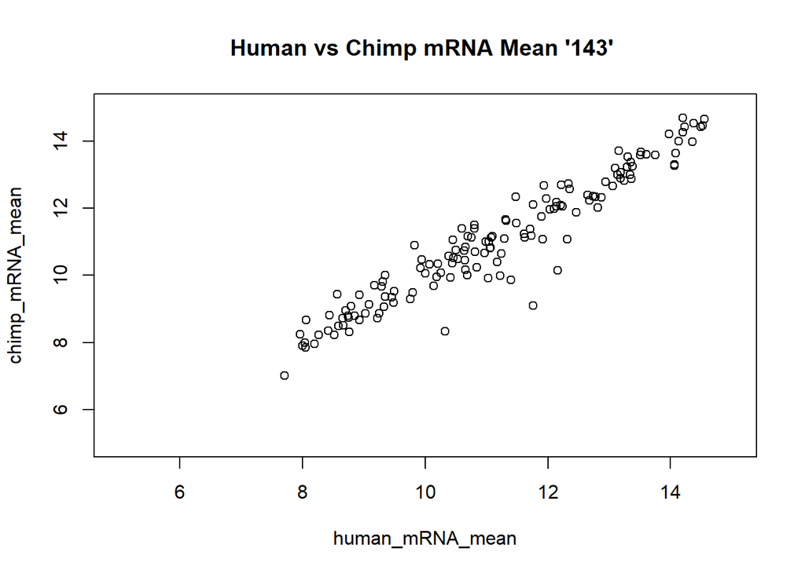

```r
#mean of Chimp mRNA on 143 proteins
chimp_mRNA_mean <- vector(length=nrow(data_143.df))
for (i in 2:nrow(data_143.df)) {
     # Calculate the row mean for columns 4 to 9
     chimp_mRNA_mean[i] <- rowMeans(data_143.df[i, 4:9])
}

#mean of Human mR of 143 proteins
human_mRNA_mean <- vector(length=nrow(data_143.df))
for (i in 2:nrow(data_143.df)) {
    # Calculate the row mean for columns 4 to 9
    human_mRNA_mean[i] <- rowMeans(data_143.df[i, 10:15])
}

plot(human_mRNA_mean, chimp_mRNA_mean, main="Human vs Chimp mRNA Mean '143' ", xlim=c(5,15), ylim=c(5,15))
```

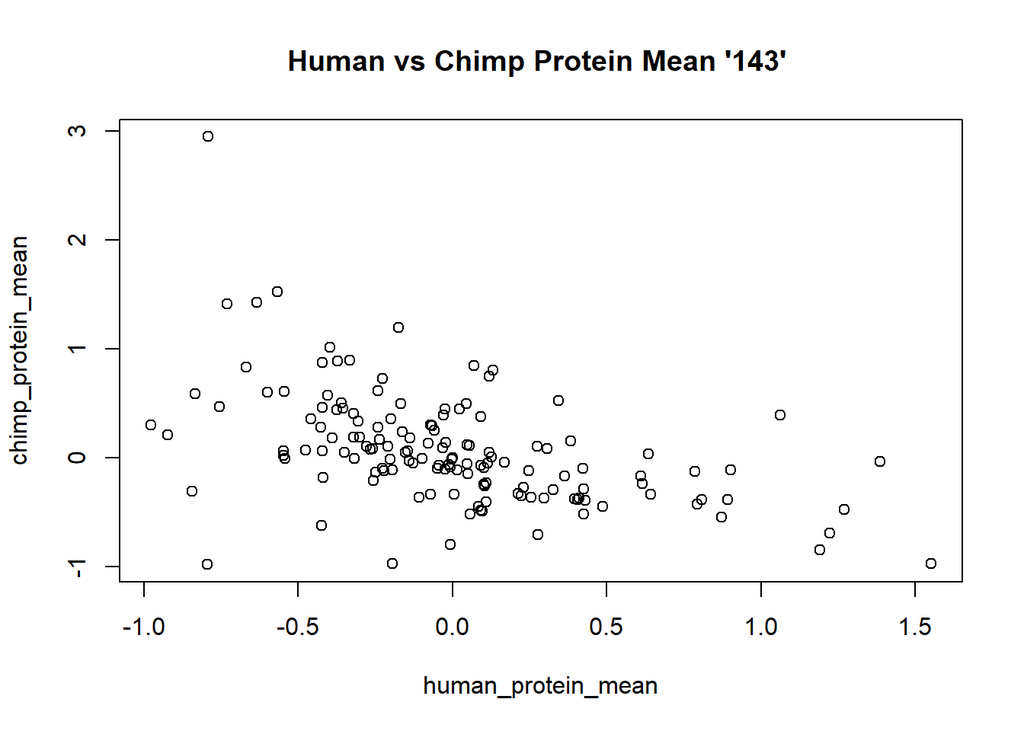

```r
#mean of Chimp protein exp on 143 proteins
chimp_protein_mean <- vector(length=nrow(data_143.df))
for (i in 2:nrow(data_143.df)) {

    chimp_protein_mean[i] <- rowMeans(data_143.df[i, 16:18])
}

#mean of human protein exp on 143 proteins
human_protein_mean <- vector(length=nrow(data_143.df))
for (i in 2:nrow(data_143.df)) {

    human_protein_mean[i] <- rowMeans(data_143.df[i, 19:21])
}

plot(human_protein_mean, chimp_protein_mean, main="Human vs Chimp Protein Mean '143' ")
```

```r
#protein 159
data_159.df <- data.frame(data_159)
data_159.df[, 4:21] <- lapply(data_159.df[, 4:21], function(x) as.numeric(as.character(x)))
```

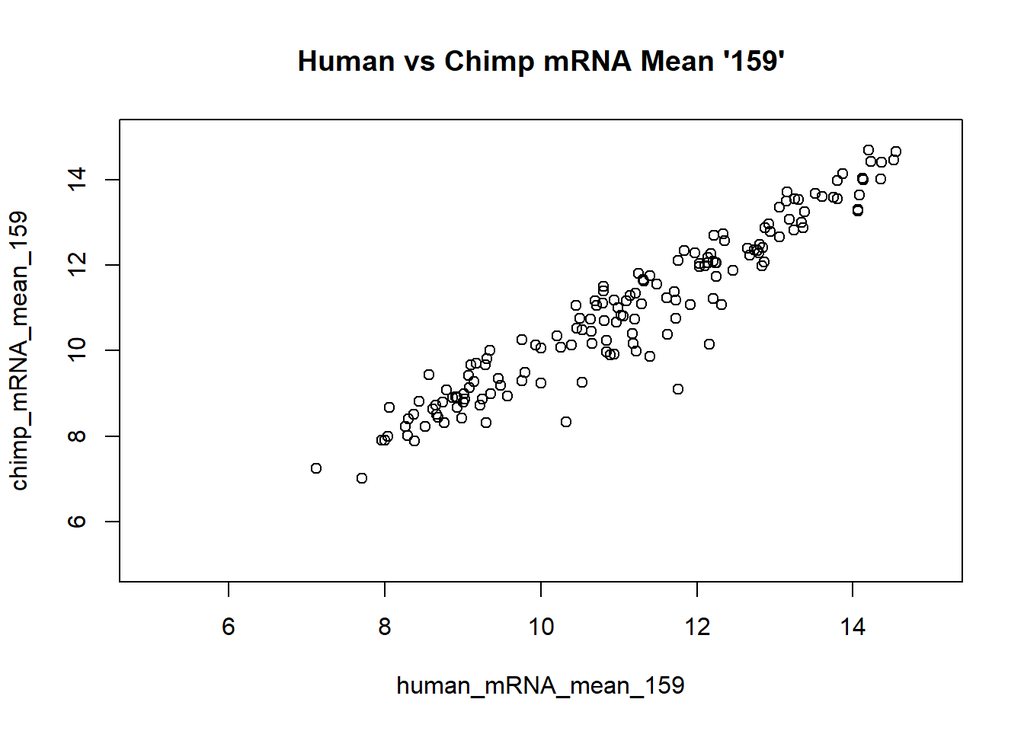

```r
#mean of Chimp mRNA on 159 proteins
chimp_mRNA_mean_159 <- vector(length=nrow(data_159.df))
for (i in 2:nrow(data_159.df)) {
     chimp_mRNA_mean_159[i] <- rowMeans(data_159.df[i, 4:9])
}

#mean of human mRNA on 159 proteins
human_mRNA_mean_159 <- vector(length=nrow(data_159.df))
for (i in 2:nrow(data_159.df)) {
     human_mRNA_mean_159[i] <- rowMeans(data_159.df[i, 10:15])
}

plot(human_mRNA_mean_159, chimp_mRNA_mean_159, main="Human vs Chimp mRNA Mean '159'",xlim=c(5,15), ylim=c(5,15))
```

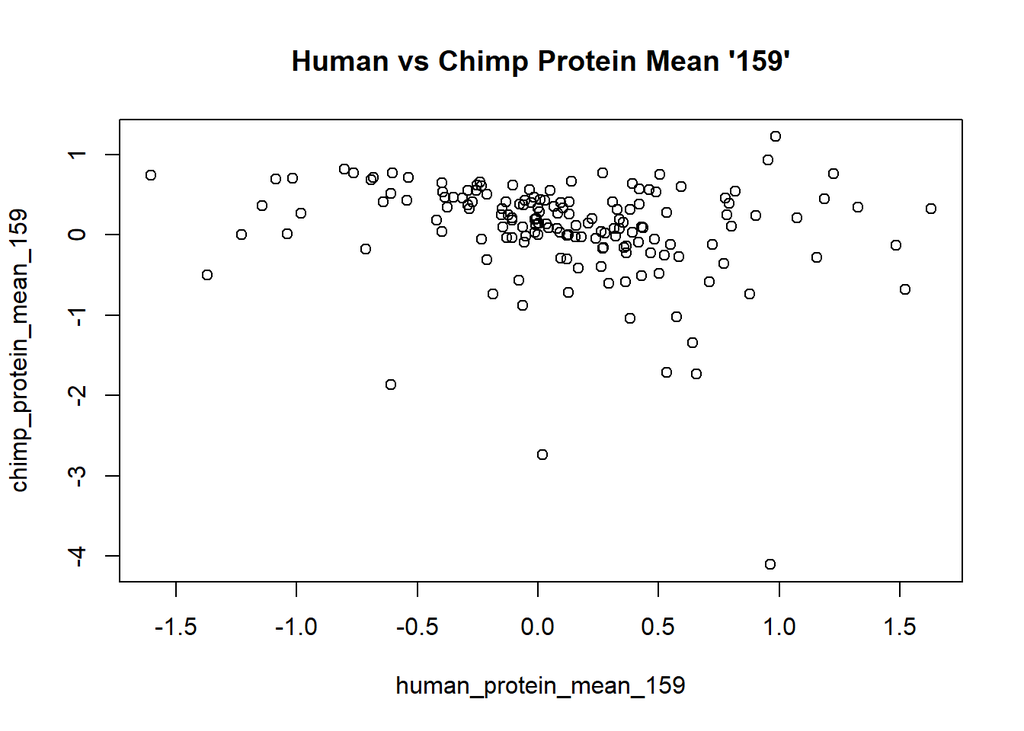

```r
#mean of chimp protein exp on 159 proteins
chimp_protein_mean_159 <- vector(length=nrow(data_159.df))
for (i in 2:nrow(data_159.df)) {
     chimp_protein_mean_159[i] <- rowMeans(data_159.df[i, 16:18])
}

#mean of human protein exp on 159 proteins
human_protein_mean_159 <- vector(length=nrow(data_159.df))
for (i in 2:nrow(data_159.df)) {
     human_protein_mean_159[i] <- rowMeans(data_159.df[i, 19:21])
}
plot(human_protein_mean_159, chimp_protein_mean_159, main="Human vs Chimp Protein Mean '159'")
```

For protein 143, the mean of human and chimp mRNA expression showed a positive correlation relationship, however, the protein mean between human and chimp was more spread out. It did have a small cluster between -0.5 to 0.5 on the x-axis. For protein 159, the mean of human and chimp mRNA expression displayed a similar trend to protein 143. There is also a similar trend when visually analyzing the human and chimp mean of protein mean compared to protein 143.

### 2. Using R function cor calculate correlations of mean mRNA levels between chimps and humans and mean protein levels between chimps and humans for both samples “143” and “159”. Compare and describe results in writing.

```r
#calculate correlation of mean mRNA between chimps and humans for protein 143
cor(human_mRNA_mean, chimp_mRNA_mean, use="complete.obs")
```

```
## [1] 0.9664414
```

```r
#calculate the correlation of mean protein expression between chimps and humans for protein 143
cor(human_protein_mean, chimp_mRNA_mean, use="complete.obs")
```

```
## [1] 0.1869685
```

```r
#calculate correlation of mean mRNA between chimps and humans for protein 159
cor(human_mRNA_mean_159, chimp_mRNA_mean_159, use="complete.obs")
```

```
## [1] 0.9652646
```

```r
#calculate correlation of mean protein expression between chimps and humans for protein 159
cor(human_protein_mean_159, chimp_protein_mean_159, use="complete.obs")
```

```
## [1] -0.2208296
```

The correlation of mRNA expression between humans and chimps for protein 143 is close to 1 which indicates a strong linear relationship between the two variables. We can see a similar relationship when we compare the mRNA expression between humans and chimp for protein 159. However, when we look at the correlation of protein expression between humans and chimps in both protein 143 and protein 159, we can see a weak linear relationship between the two variables and lack of association between the two.

### 3. Fit four linear models for the following relationships: mean mRNA(human) vs mean mRNA(chimp), mean protein level (human) vs mean protein level (chimp), in each of the samples “143” and “159”. Present summary and model diagnostics, anova analysis of relationship significance, compare and describe results in plain English.

```r
#linear model for mean mRNA human vs. chimp + mean protein exp human vs. chimp for protein143
mRNA_143.lm <- lm(human_mRNA_mean~chimp_mRNA_mean, data=na.omit(data_143.df))
protein_143.lm <- lm(human_protein_mean~chimp_protein_mean, data=na.omit(data_143.df))
#linear model for mean RNA human vs. chimp + mean protein exp human vs. chimp for protein159
mRNA_159.lm <- lm(human_mRNA_mean_159~chimp_mRNA_mean_159, data=na.omit(data_159.df))
protein_159.lm <- lm(human_protein_mean_159~chimp_protein_mean_159, data=na.omit(data_159.df))
#summary
summary(mRNA_143.lm);summary(protein_143.lm)
```

```
##
## Call:
## lm(formula = human_mRNA_mean ~ chimp_mRNA_mean, data = na.omit(data_143.df))
##
## Residuals:
##      Min       1Q   Median       3Q      Max
## -1.18735 -0.26823 -0.03038  0.24077  2.49489
##
## Coefficients:
##                 Estimate Std. Error t value Pr(>|t|)
## (Intercept)      0.45145    0.24085   1.874   0.0629 .
## chimp_mRNA_mean  0.96917    0.02162  44.831   <2e-16 ***
## ---
## Signif. codes:  0 '***' 0.001 '**' 0.01 '*' 0.05 '.' 0.1 ' ' 1
##
## Residual standard error: 0.5292 on 142 degrees of freedom
##   (3 observations deleted due to missingness)
## Multiple R-squared:  0.934,  Adjusted R-squared:  0.9335
## F-statistic:  2010 on 1 and 142 DF,  p-value: < 2.2e-16
```

```
##
## Call:
## lm(formula = human_protein_mean ~ chimp_protein_mean, data = na.omit(data_143.df))
##
## Residuals:
##      Min       1Q   Median       3Q      Max
## -1.26019 -0.23594 -0.03514  0.17628  1.34597
##
## Coefficients:
##                    Estimate Std. Error t value Pr(>|t|)
## (Intercept)         0.02416    0.03409   0.709     0.48
## chimp_protein_mean -0.44951    0.06507  -6.908 1.52e-10 ***
## ---
## Signif. codes:  0 '***' 0.001 '**' 0.01 '*' 0.05 '.' 0.1 ' ' 1
##
## Residual standard error: 0.4057 on 142 degrees of freedom
##   (3 observations deleted due to missingness)
## Multiple R-squared:  0.2516, Adjusted R-squared:  0.2463
## F-statistic: 47.73 on 1 and 142 DF,  p-value: 1.519e-10
```

```r
summary(mRNA_159.lm);summary(protein_159.lm)
```

```
##
## Call:
## lm(formula = human_mRNA_mean_159 ~ chimp_mRNA_mean_159, data = na.omit(data_159.df))
##
## Residuals:
##      Min       1Q   Median       3Q      Max
## -1.09786 -0.32653 -0.05578  0.26921  2.42075
##
## Coefficients:
##                     Estimate Std. Error t value Pr(>|t|)
## (Intercept)          0.61476    0.22828   2.693  0.00784 **
## chimp_mRNA_mean_159  0.95937    0.02066  46.439  < 2e-16 ***
## ---
## Signif. codes:  0 '***' 0.001 '**' 0.01 '*' 0.05 '.' 0.1 ' ' 1
##
## Residual standard error: 0.5304 on 158 degrees of freedom
##   (3 observations deleted due to missingness)
## Multiple R-squared:  0.9317, Adjusted R-squared:  0.9313
## F-statistic:  2157 on 1 and 158 DF,  p-value: < 2.2e-16
```

```
##
## Call:
## lm(formula = human_protein_mean_159 ~ chimp_protein_mean_159,
##     data = na.omit(data_159.df))
##
## Residuals:
##      Min       1Q   Median       3Q      Max
## -1.59219 -0.25558 -0.00733  0.26312  1.56388
##
## Coefficients:
##                        Estimate Std. Error t value Pr(>|t|)
## (Intercept)             0.12727    0.04294   2.964  0.00351 **
## chimp_protein_mean_159 -0.19059    0.06697  -2.846  0.00501 **
## ---
## Signif. codes:  0 '***' 0.001 '**' 0.01 '*' 0.05 '.' 0.1 ' ' 1
##
## Residual standard error: 0.5388 on 158 degrees of freedom
##   (3 observations deleted due to missingness)
## Multiple R-squared:  0.04877,    Adjusted R-squared:  0.04275
## F-statistic:   8.1 on 1 and 158 DF,  p-value: 0.005014
```

```r
#anova
anova(mRNA_143.lm); anova(protein_143.lm)
```

```
## Analysis of Variance Table
##
## Response: human_mRNA_mean
##                  Df Sum Sq Mean Sq F value    Pr(>F)
## chimp_mRNA_mean   1 562.79  562.79  2009.8 < 2.2e-16 ***
## Residuals       142  39.76    0.28
## ---
## Signif. codes:  0 '***' 0.001 '**' 0.01 '*' 0.05 '.' 0.1 ' ' 1
```

```
## Analysis of Variance Table
##
## Response: human_protein_mean
##                     Df  Sum Sq Mean Sq F value    Pr(>F)
## chimp_protein_mean   1  7.8546  7.8546  47.726 1.519e-10 ***
## Residuals          142 23.3700  0.1646
## ---
## Signif. codes:  0 '***' 0.001 '**' 0.01 '*' 0.05 '.' 0.1 ' ' 1
```

```r
anova(mRNA_159.lm); anova(protein_159.lm)
```

```
## Analysis of Variance Table
##
## Response: human_mRNA_mean_159
##                      Df Sum Sq Mean Sq F value    Pr(>F)
## chimp_mRNA_mean_159   1 606.78  606.78  2156.5 < 2.2e-16 ***
## Residuals           158  44.46    0.28
## ---
## Signif. codes:  0 '***' 0.001 '**' 0.01 '*' 0.05 '.' 0.1 ' ' 1
```

```
## Analysis of Variance Table
##
## Response: human_protein_mean_159
##                         Df Sum Sq Mean Sq F value   Pr(>F)
## chimp_protein_mean_159   1  2.352 2.35191     8.1 0.005014 **
## Residuals              158 45.877 0.29036
## ---
## Signif. codes:  0 '***' 0.001 '**' 0.01 '*' 0.05 '.' 0.1 ' ' 1
```

### 4. Draw plots representing relationship between mean mRNA and protein levels for each species, in each of the samples. Describe results of their comparison.

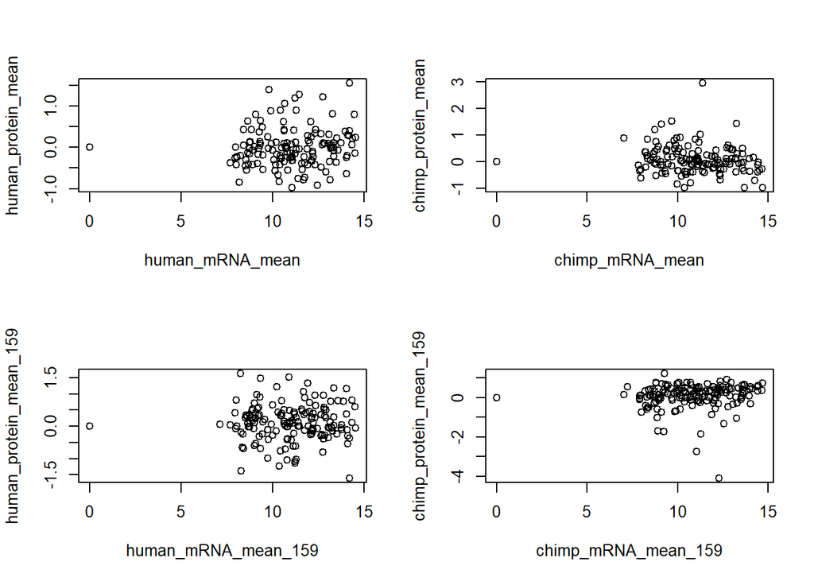

```r
par(mfrow=c(2,2))
plot(human_mRNA_mean, human_protein_mean)
plot(chimp_mRNA_mean, chimp_protein_mean)
plot(human_mRNA_mean_159, human_protein_mean_159)
plot(chimp_mRNA_mean_159, chimp_protein_mean_159)
```

In humans, protein 143 and protein 159 comparing mean of mRNA and mean of protein expression showed similar results. Scatter plots clustered in the same area with slight differences in mean protein expression with protein 143 being slightly lower than protein 159. In chimps, protein 143 and protein 159 had some differences. Although the cluster is between 6 to 15 for mRNA for both protein 143 and protein 159, there are differences in protein expression. The scatter plot shows that the protein 143 gathers around the -1 to 1 for protein expression with a few outliers going above 1. In protein 159, there are outliers towards -4.

### 5. Calculate differences between mean mRNA levels for human and chimps and mean protein levels for human and chimps. Plot these differences –difference in protein levels vs difference in mRNA levels, for both samples. These are the relationships represented by panel A and C in supplementary figure S2 – compare and describe results.

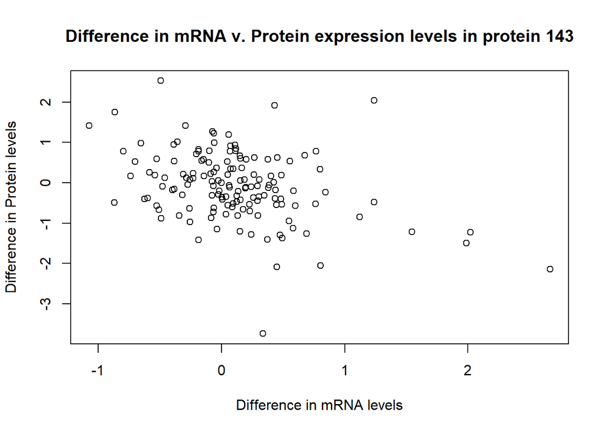

```r
#calculate differences
diff_mRNA_143 <- na.omit(human_mRNA_mean) - na.omit(chimp_mRNA_mean)
diff_protein_143 <- na.omit(human_protein_mean) - na.omit(chimp_protein_mean)
diff_mRNA_159 <- na.omit(human_mRNA_mean_159) - na.omit(chimp_mRNA_mean_159)
diff_protein_159 <- na.omit(human_protein_mean_159) - na.omit(chimp_protein_mean_159)
#plot differences

plot(diff_mRNA_143, diff_protein_143, xlab="Difference in mRNA levels", ylab="Difference in Protein levels", main="Difference in mRNA v. Protein expression levels in protein 143")
```

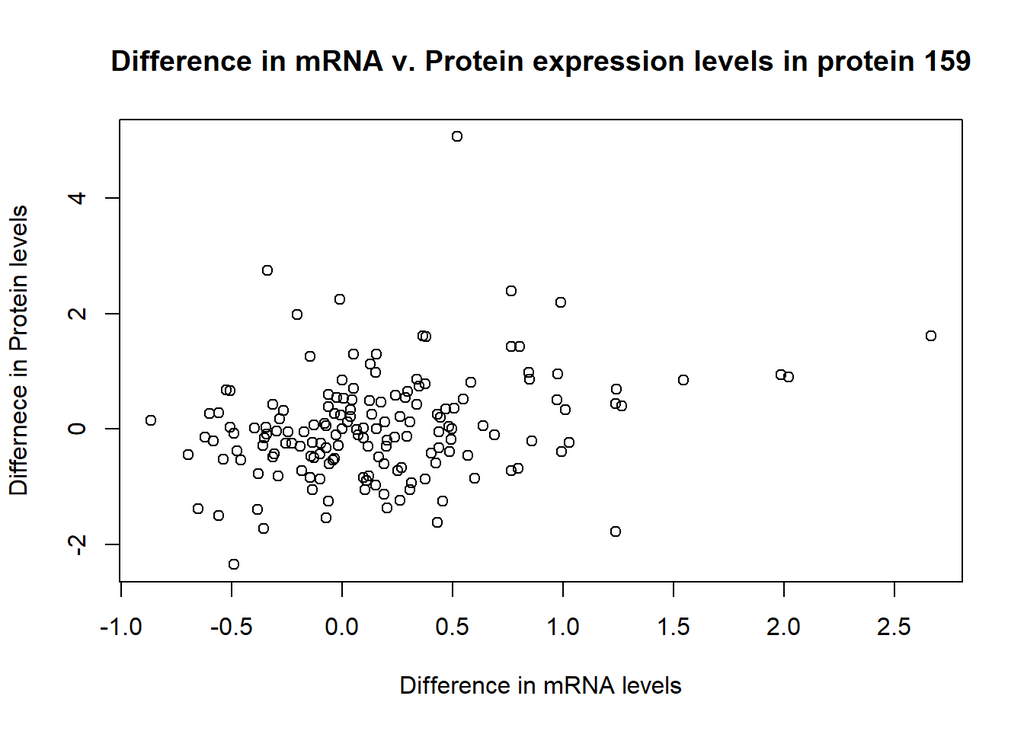

```r
plot(diff_mRNA_159, diff_protein_159, xlab="Difference in mRNA levels", ylab="Differnece in Protein levels", main="Difference in mRNA v. Protein expression levels in protein 159")
```

The data visualization of the differences between mRNA and protein expression in protein 143 and 159 show that there are is a weak relationship between the two variables. The differences between mRNA or protein expression between species demonstrates that the changes in mRNA level do not strongly correlate with the changes in protein levels.

### 6. Calculate correlation coefficients for differences between human and chimp protein and mRNA levels from problem 5. Do it for both samples. These are the correlations presented in the final sentence in the article's "Results" section – compare and describe results.

```r
cor(diff_protein_143, diff_mRNA_143, use="complete.obs")
```

```
## [1] -0.3729839
```

```r
cor(diff_protein_159, diff_mRNA_159, use="complete.obs")
```

```
## [1] 0.2744741
```

Protein 149 showed weak correlation between the differences between human and chimp protein and mRNA levels while protein 159 showed positive correlation between the human and chimp protein and mRNA levels.

### 7. Fit two linear models – one for each sample – on the relationships between differences of mean RNA levels for humans and chimps vs differences of mean protein levels for humans and chimps. Present summary and diagnostics, anova significance assessment of the relationship – compare and describe results in plain English.

```r
#linear model of diff between mRNA between human+chimp and diff between protein expression between human+chimp for protein 143
diff_143.lm <- lm(human_protein_mean - chimp_protein_mean ~ human_mRNA_mean - chimp_mRNA_mean)
#linear model of diff between mRNA between human+chimp and diff between protein expression between human+chimp for protein 159
diff_159.lm <- lm(human_protein_mean_159 - chimp_protein_mean_159~ human_mRNA_mean_159 - chimp_mRNA_mean_159)
#Summary
summary(diff_143.lm); summary(diff_159.lm)
```

```
##
## Call:
## lm(formula = human_protein_mean - chimp_protein_mean ~ human_mRNA_mean -
##     chimp_mRNA_mean)
##
## Residuals:
##     Min      1Q  Median      3Q     Max
## -3.6933 -0.4679  0.0107  0.5462  2.4698
##
## Coefficients:
##                 Estimate Std. Error t value Pr(>|t|)
## (Intercept)     -0.53387    0.39235  -1.361    0.176
## human_mRNA_mean  0.04163    0.03486   1.194    0.234
##
## Residual standard error: 0.8558 on 142 degrees of freedom
##   (3 observations deleted due to missingness)
## Multiple R-squared:  0.009941,   Adjusted R-squared:  0.002969
## F-statistic: 1.426 on 1 and 142 DF,  p-value: 0.2344
```

```
##
## Call:
## lm(formula = human_protein_mean_159 - chimp_protein_mean_159 ~
##     human_mRNA_mean_159 - chimp_mRNA_mean_159)
##
## Residuals:
##     Min      1Q  Median      3Q     Max
## -2.3526 -0.5180 -0.0668  0.4541  5.0531
##
## Coefficients:
##                      Estimate Std. Error t value Pr(>|t|)
## (Intercept)          0.134826   0.410230   0.329    0.743
## human_mRNA_mean_159 -0.009351   0.036569  -0.256    0.799
##
## Residual standard error: 0.9332 on 158 degrees of freedom
##   (3 observations deleted due to missingness)
## Multiple R-squared:  0.0004137,  Adjusted R-squared:  -0.005913
## F-statistic: 0.06539 on 1 and 158 DF,  p-value: 0.7985
```

```r
#ANOVA
anova(diff_143.lm); anova(diff_159.lm)
```

```
## Analysis of Variance Table
##
## Response: human_protein_mean - chimp_protein_mean
##                  Df  Sum Sq Mean Sq F value Pr(>F)
## human_mRNA_mean   1   1.044  1.0443  1.4258 0.2344
## Residuals       142 104.000  0.7324
```

```
## Analysis of Variance Table
##
## Response: human_protein_mean_159 - chimp_protein_mean_159
##                      Df  Sum Sq Mean Sq F value Pr(>F)
## human_mRNA_mean_159   1   0.057 0.05694  0.0654 0.7985
## Residuals           158 137.597 0.87086
```

The p-values for both linear models were above 0.05, therefore I have to conclude that there is not significance association. The ANOVA test for both linear models has interpreted that humans and chimp for both protein 143 and 159 does not show significant relationship between the difference in mRNA and protein expression levels.

### 8. For each gene run two t-tests contrasting humans and chimps using replicated measurements of its 1) mRNA levels, then 2) protein levels.

Use assumption of equal variances as this is what mentioning of “Student’s t-test” in the manuscript implies. Plot these p-values as two histograms (for mRNA and protein levels, respectively). Also generate X-Y scatterplot of these pvalues (p-value for protein level difference vs p-value for mRNA level difference between human and chimp). Repeat for both samples. Compare number of differences with p-values under 0.01 in all these comparisons with what is reported in the manuscript (last paragraph of section “Results”). Describe results of such comparison.

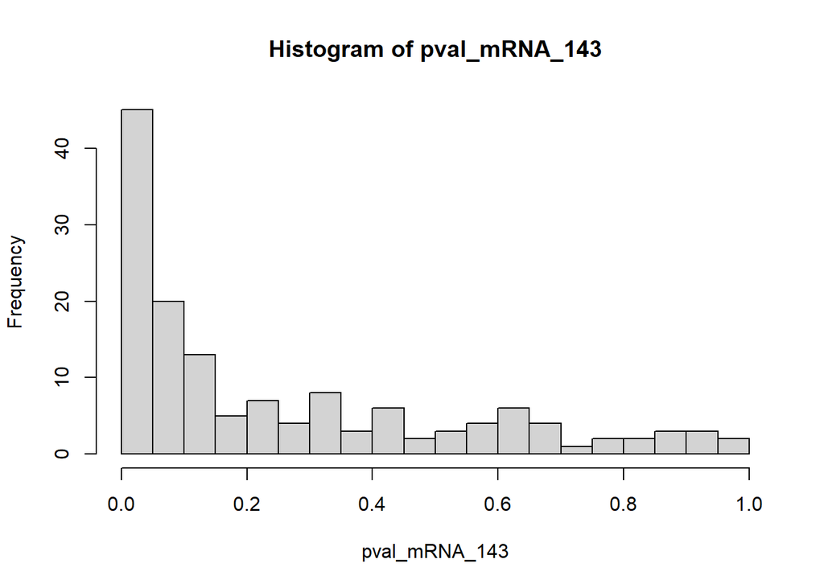

```r
#empty vectors to store my pvals
pval_mRNA_143 <- c()
pval_mRNA_159 <- c()
pval_protein_143 <- c()
pval_protein_159 <- c()

##t-test for mRNA levels b/w humans and chimps protein 143
for (i in 2:nrow(data_143.df)) {
    if (any(is.na(data_143.df[i, c(4:9, 10:15)]))) {
        next  # Skips NAs in .df
    }
    mRNA_143_ttest <- t.test(data_143.df[i, 4:9], data_143.df[i, 10:15], var.equal = TRUE)
    pval_mRNA_143 <- c(pval_mRNA_143, mRNA_143_ttest$p.value)
    #print(paste("T-test for row", i, "completed.")) <- used this to confirm that it looped every row
}

#t-test for protein expression levels b/w humans and chimps protein 143
for (i in 2:nrow(data_143.df)) {
    if (any(is.na(data_143.df[i, c(16:18, 19:21)]))) {
        next  # Skip this row if it contains any missing values
    }
    protein_143_ttest <- t.test(data_143.df[i, 16:18], data_143.df[i, 19:21], var.equal = TRUE)
    pval_protein_143 <- c(pval_protein_143, protein_143_ttest$p.value)
}
#t-test for mRNA levels b/w humans and chimps protein 159
for (i in 2:nrow(data_159.df)) {
    if (any(is.na(data_159.df[i, c(4:9, 10:15)]))) {
        next  # Skip NAs in .df
    }
    mRNA_159_ttest <- t.test(data_159.df[i, 4:9], data_159.df[i, 10:15], var.equal = TRUE)
    pval_mRNA_159 <- c(pval_mRNA_159, mRNA_159_ttest$p.value)
}
#t-test for protein expression levels b/w humans and chimps protein 159

for (i in 2:nrow(data_159.df)) {
    if (any(is.na(data_159.df[i, c(16:18, 19:21)]))) {
        next  # Skip this row if it contains any missing values
    }
    protein_159_ttest <- t.test(data_159.df[i, 16:18], data_159.df[i, 19:21], var.equal = TRUE)
    pval_protein_159 <- c(pval_protein_159, protein_159_ttest$p.value)
}

#histogram  mRNA level and protein level of protein 143
hist(pval_mRNA_143, breaks=20)
```

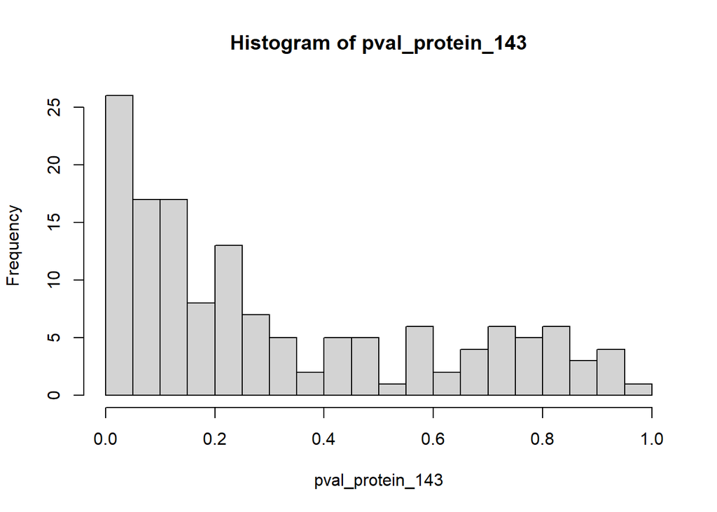

```r
hist(pval_protein_143, breaks=20)
```

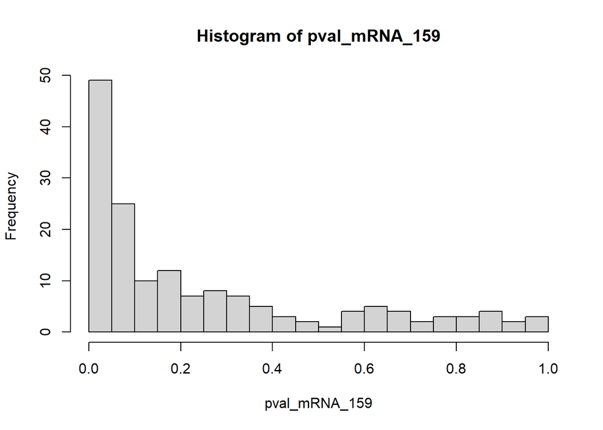

```r
#histogram mRNA level and protein level of protein 159
hist(pval_mRNA_159, breaks=20)
```

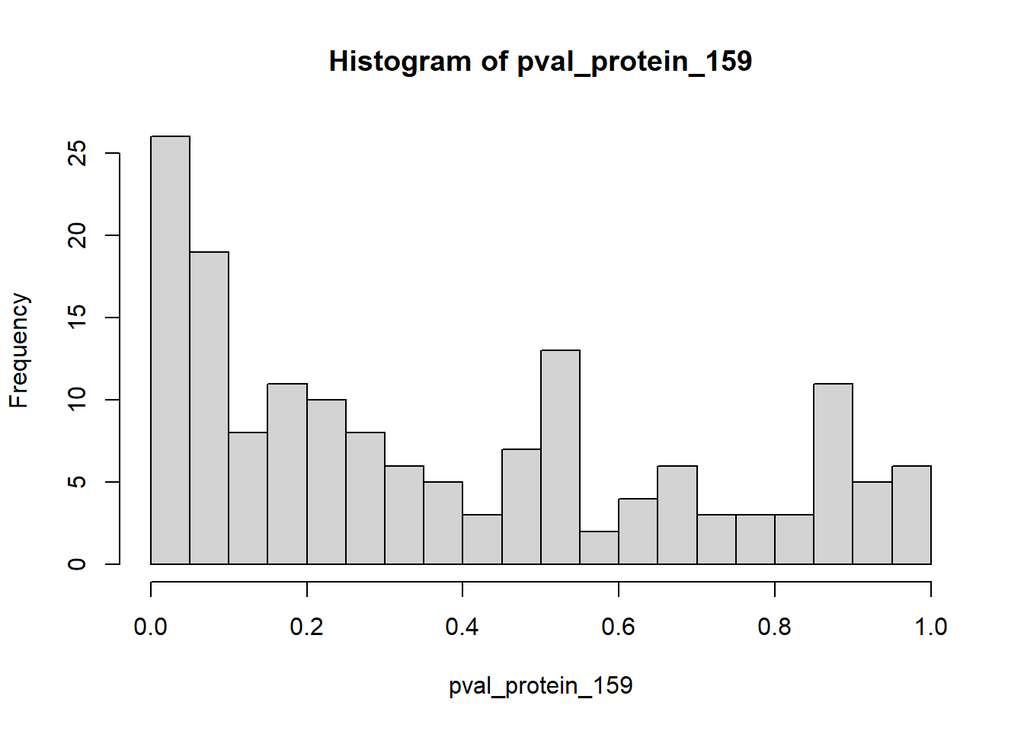

```r
hist(pval_protein_159, breaks=20)
```

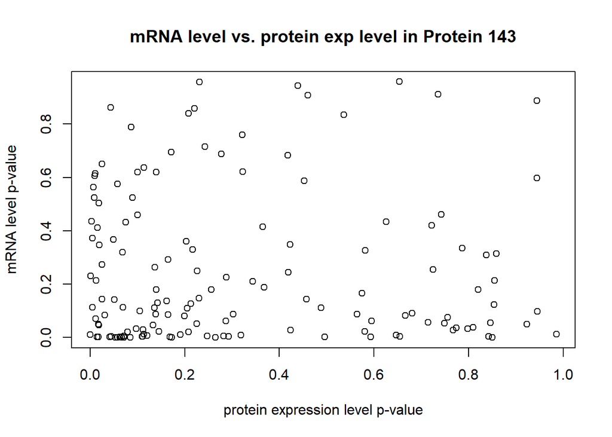

```r
#x-y scatterplot of p-vals protein level vs mRNA protein 143
plot(pval_protein_143, pval_mRNA_143, xlab="protein expression level p-value", ylab="mRNA level p-value", main="mRNA level vs. protein exp level in Protein 143")
```

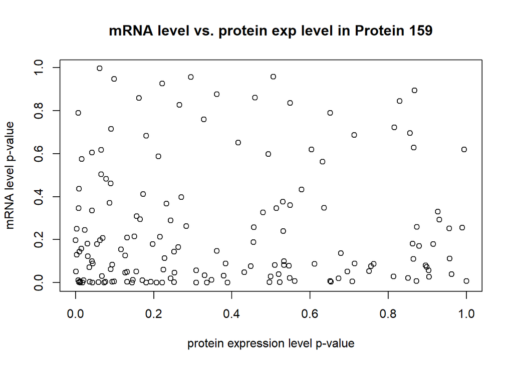

```r
#x-y scatterplot of pvals protein level vs mRNA protein 159
plot(pval_protein_159, pval_mRNA_159, xlab="protein expression level p-value", ylab="mRNA level p-value", main="mRNA level vs. protein exp level in Protein 159")
```

```r
# Count p-values less than 0.01 for mRNA 143
n_pval_mRNA_143 <- sum(pval_mRNA_143 < 0.01) ; n_pval_mRNA_143
```

```
## [1] 28
```

```r
# Count p-values less than 0.01 for protein 143
n_pval_protein_143 <- sum(pval_protein_143 < 0.01) ; n_pval_protein_143
```

```
## [1] 8
```

```r
# Count p-values less than 0.01 for mRNA 159
n_pval_mRNA_159 <- sum(pval_mRNA_159 < 0.01); n_pval_mRNA_159
```

```
## [1] 29
```

```r
# Count p-values less than 0.01 for protein 159
n_pval_protein_159 <- sum(pval_protein_159 < 0.01); n_pval_protein_159
```

```
## [1] 10
```

There are 28 genes with significant mRNA expression difference and 8 genes with significant protein expression level difference in species in protein 143. There are 29 genes with significant mRNA expression difference and 10 genes with significant protein expression level difference in species in protein 159. Having a p-value of less than 0.01 suggests that the difference s statistically significant. The manuscript had 24 and 23 genes with significant mRNA expression difference compared to my calculations of 28 and 29 genes for 143 and 159 genes respectively.

```r
#empty vectors to store my pvals
pval_mRNA_143.2 <- c()
pval_mRNA_159.2 <- c()
pval_protein_143.2 <- c()
pval_protein_159.2 <- c()
pval_mRNA_143_lm <- c()
pval_protein_143_lm <- c()
pval_mRNA_159_lm <- c()
pval_protein_159_lm <- c()
##t-test for mRNA levels b/w humans and chimps protein 143 unequal variances
for (i in 2:nrow(data_143.df)) {
    if (any(is.na(data_143.df[i, c(4:9, 10:15)]))) {
        next  # Skips NAs in .df
    }
    mRNA_143_ttest.2 <- t.test(data_143.df[i, 4:9], data_143.df[i, 10:15], var.equal = FALSE)
    pval_mRNA_143.2 <- c(pval_mRNA_143.2, mRNA_143_ttest.2$p.value)
    #linear model and anova

    lm_mRNA_143 <- lm(unlist(data_143.df[i, c(4:9)]) ~ unlist(data_143.df[i, c(10:15)]))

    anova_mRNA_143 <- anova(lm_mRNA_143)
    pval_mRNA_143_lm <- c(pval_mRNA_143_lm, anova_mRNA_143[[1,"Pr(>F)"]])
}

#t-test for protein expression levels b/w humans and chimps protein 143 unequal variance

for (i in 2:nrow(data_143.df)) {
    if (any(is.na(data_143.df[i, c(16:18, 19:21)]))) {
        next
    }
    protein_143_ttest.2 <- t.test(data_143.df[i, 16:18], data_143.df[i, 19:21], var.equal = FALSE)
    pval_protein_143.2 <- c(pval_protein_143.2, protein_143_ttest.2$p.value)
    #linear model and anova

    lm_protein_143 <- lm(unlist(data_143.df[i, c(16:18)]) ~ unlist(data_143.df[i, c(19:21)]))
    anova_protein_143 <- anova(lm_protein_143)
    pval_protein_143_lm <- c(pval_protein_143_lm, anova_protein_143[[1,"Pr(>F)"]])
}
##t-test for mRNA levels b/w humans and chimps protein 159 unequal variances
for (i in 2:nrow(data_159.df)) {
    if (any(is.na(data_159.df[i, c(4:9, 10:15)]))) {
        next  # Skips NAs in .df
    }
    mRNA_159_ttest.2 <- t.test(data_159.df[i, 4:9], data_159.df[i, 10:15], var.equal = FALSE)
    pval_mRNA_159.2 <- c(pval_mRNA_159.2, mRNA_159_ttest.2$p.value)
    #linear model and anova

    lm_mRNA_159 <- lm(unlist(data_159.df[i, c(4:9)]) ~ unlist(data_159.df[i, c(10:15)]))
    anova_mRNA_159 <- anova(lm_mRNA_159)
    pval_mRNA_159_lm <- c(pval_mRNA_159_lm, anova_mRNA_159[[1,"Pr(>F)"]])
}

#t-test for protein expression levels b/w humans and chimps protein 159 unequal variance

for (i in 2:nrow(data_159.df)) {
    if (any(is.na(data_159.df[i, c(16:18, 19:21)]))) {
        next
    }
    protein_159_ttest.2 <- t.test(data_159.df[i, 16:18], data_159.df[i, 19:21], var.equal = FALSE)
    pval_protein_159.2 <- c(pval_protein_159.2, protein_159_ttest.2$p.value)
    #linear model and anova

    lm_protein_159 <- lm(unlist(data_159.df[i, c(16:18)]) ~ unlist(data_159.df[i, c(19:21)]))
    anova_protein_159 <- anova(lm_protein_159)
    pval_protein_159_lm <- c(pval_protein_159_lm, anova_protein_159[[1,"Pr(>F)"]])
}
```

### 10. Find genes represented both in “143” and “159” data sets by identifying RefSeq ID present in both. [Hint: c(“a”,”b”,”c”)[c(“a”,”b”,”c”) %in% c(“b”,”c”,”d”)] will return “b” and “c”.] Plot XY-scatter plots of 1) mean human mRNA expression levels in the two samples (for the genes shared between the samples); 2) mean human protein levels in the two samples; 3) mean chimp mRNA levels in the two samples, and 4) mean chimp protein levels in the two samples. (e.g. mean human RNA level in “143” dataset versus mean human RNA level in “159” dataset for the same genes, etc.). Discuss the results.

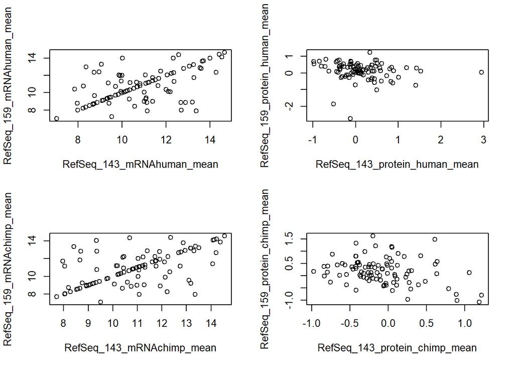

```r
#Save RefSeqID in variable
RefSeqID_143<-data_143.df$RefSeq..ID[2:144]
RefSeqID_159<-data_159.df$RefSeq..ID[2:160]

#Save matching indices
matching_indices_143 <- which(RefSeqID_143 %in% RefSeqID_159)
RefSeqID_143.df <- data.frame(data_143.df[matching_indices_143,])
matching_indices_159 <- which(RefSeqID_159 %in% RefSeqID_143)
RefSeqID_159.df <- data.frame(data_159.df[matching_indices_159,])

#mean of mRNA expression human and chimp in protein 143
RefSeq_143_mRNAhuman_mean <- c()
for (i in 2:nrow(RefSeqID_143.df)){
  RefSeq_143_mRNAhuman_mean[i] <- rowMeans(RefSeqID_143.df[i, 4:9])
}

RefSeq_143_mRNAchimp_mean <-c()
for (i in 2:nrow(RefSeqID_143.df)){
  RefSeq_143_mRNAchimp_mean[i] <- rowMeans(RefSeqID_143.df[i, 10:15])
}

#mean of protein level human and chimp in protein 143
RefSeq_143_protein_human_mean <- c()
for (i in 2:nrow(RefSeqID_143.df)){
  RefSeq_143_protein_human_mean[i] <- rowMeans(RefSeqID_143.df[i, 16:18])
}

RefSeq_143_protein_chimp_mean <-c()
for (i in 2:nrow(RefSeqID_143.df)){
  RefSeq_143_protein_chimp_mean[i] <- rowMeans(RefSeqID_143.df[i, 19:21])
}

#mean of mRNA expression human and chimp in protein 159
RefSeq_159_mRNAhuman_mean <- c()
for (i in 2:nrow(RefSeqID_159.df)){
  RefSeq_159_mRNAhuman_mean[i] <- rowMeans(RefSeqID_159.df[i, 4:9])
}

RefSeq_159_mRNAchimp_mean <-c()
for (i in 2:nrow(RefSeqID_159.df)){
  RefSeq_159_mRNAchimp_mean[i] <- rowMeans(RefSeqID_159.df[i, 10:15])
}

#mean of protein level human and chimp in protein 159
RefSeq_159_protein_human_mean <- c()
for (i in 2:nrow(RefSeqID_159.df)){
  RefSeq_159_protein_human_mean[i] <- rowMeans(RefSeqID_159.df[i, 16:18])
}

RefSeq_159_protein_chimp_mean <-c()
for (i in 2:nrow(RefSeqID_159.df)){
  RefSeq_159_protein_chimp_mean[i] <- rowMeans(RefSeqID_159.df[i, 19:21])
}

#plot xy mean mRNA
par(mfrow=c(2,2))
plot(RefSeq_143_mRNAhuman_mean, RefSeq_159_mRNAhuman_mean)
plot(RefSeq_143_protein_human_mean, RefSeq_159_protein_human_mean)

plot(RefSeq_143_mRNAchimp_mean, RefSeq_159_mRNAchimp_mean,)
plot(RefSeq_143_protein_chimp_mean, RefSeq_159_protein_chimp_mean)
```

For mean human mRNA levels in protein 143 and 159, there were matching means. Though there were matching genes represented in protein 143 and 159, the mRNA expression levels were not the same across the genes. For mean protein levels in humans, there doesn’t seem to be any identical means between protein 143 and 159 but the means are quite close as they are clustered in an area of the graph. We see a similar trend when we compare mean chimp mRNA levels in protein 143 and 159 the positive trend of data plots represents the identical mean mRNA levels shared between both proteins. However,for mean chimp protein levels, there is no trend in the shared gened represented in protein 143 and 159.

### 11. Compare reproducibility of each of the readouts (mRNA, protein, human, chimp) between these two dataset by running t-test on their replicate measurements in these two samples (i.e. contrast a sample of human mRNA expression level measurements in sample 143 vs a sample of mRNA expression level measurements in sample 159, for each gene, etc). Present results as distribution of p-values, compare them with p-values from contrasting humans and chimps in each sample, discuss the results in writing.

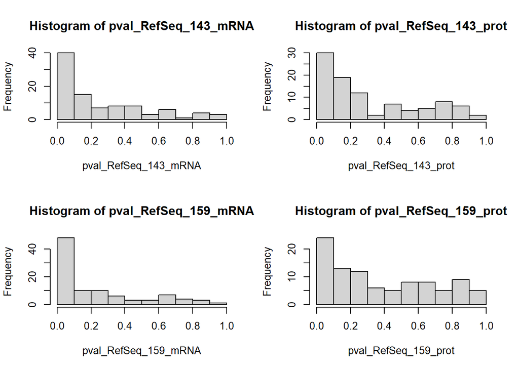

```r
#t-test
pval_RefSeq_143_mRNA <- c()
pval_RefSeq_143_prot <- c()
pval_RefSeq_159_mRNA <- c()
pval_RefSeq_159_prot <- c()

for (i in 2:nrow(RefSeqID_143.df)) {
    if (any(is.na(RefSeqID_143.df[i, c(4:9, 10:15)]))) {
        next  # Skips NAs in .df
    }
    RefSeq_143_mRNA.tt <- t.test(RefSeqID_143.df[i, 4:9], RefSeqID_143.df[i, 10:15])
    pval_RefSeq_143_mRNA <- c(pval_RefSeq_143_mRNA, RefSeq_143_mRNA.tt$p.value)
    #print(paste("T-test for row", i, "completed.")) <- used this to confirm that it looped every row
}

#t-test for protein expression levels b/w humans and chimps protein 143
for (i in 2:nrow(RefSeqID_143.df)) {
    if (any(is.na(RefSeqID_143.df[i, c(16:18, 19:21)]))) {
        next  # Skip this row if it contains any missing values
    }
    RefSeq_143_prot.tt <- t.test(RefSeqID_143.df[i, 16:18], RefSeqID_143.df[i, 19:21], var.equal = TRUE)
    pval_RefSeq_143_prot <- c(pval_RefSeq_143_prot, RefSeq_143_prot.tt$p.value)
}
#t-test for mRNA levels b/w humans and chimps protein 159
for (i in 2:nrow(RefSeqID_159.df)) {
    if (any(is.na(RefSeqID_159.df[i, c(4:9, 10:15)]))) {
        next  # Skip NAs in .df
    }
    RefSeq_159_mRNA.tt <- t.test(RefSeqID_159.df[i, 4:9], RefSeqID_159.df[i, 10:15], var.equal = TRUE)
    pval_RefSeq_159_mRNA <- c(pval_RefSeq_159_mRNA, RefSeq_159_mRNA.tt$p.value)
}
#t-test for protein expression levels b/w humans and chimps protein 159

for (i in 2:nrow(RefSeqID_159.df)) {
    if (any(is.na(RefSeqID_159.df[i, c(16:18, 19:21)]))) {
        next  # Skip this row if it contains any missing values
    }
    RefSeq_159_prot.tt <- t.test(RefSeqID_159.df[i, 16:18], RefSeqID_159.df[i, 19:21], var.equal = TRUE)
    pval_RefSeq_159_prot <- c(pval_RefSeq_159_prot, RefSeq_159_prot.tt$p.value)
}

par(mfrow=c(2,2)); hist(pval_RefSeq_143_mRNA);hist(pval_RefSeq_143_prot); hist(pval_RefSeq_159_mRNA); hist(pval_RefSeq_159_prot)
```

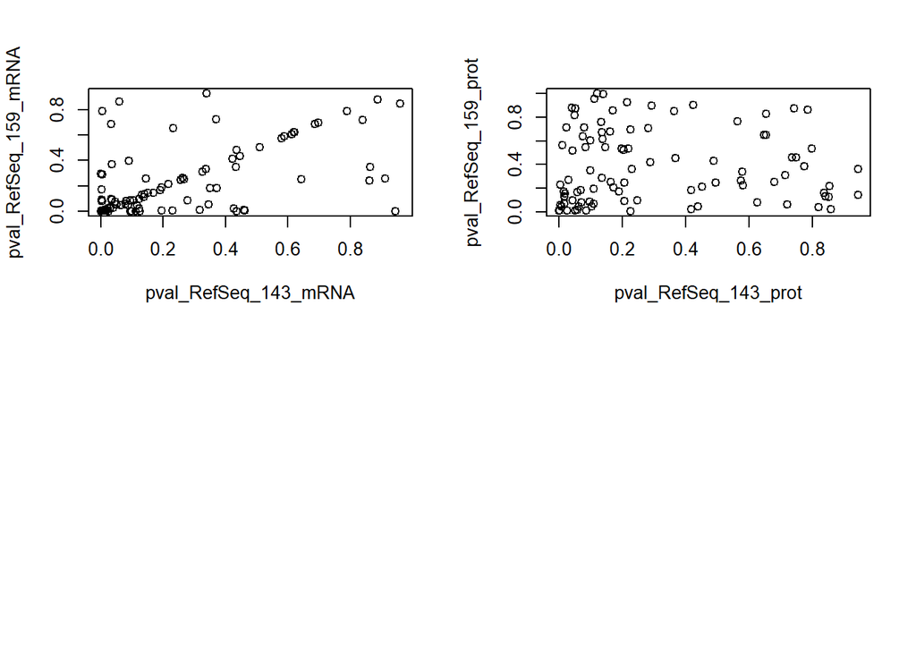

```r
plot(pval_RefSeq_143_mRNA, pval_RefSeq_159_mRNA);plot(pval_RefSeq_143_prot, pval_RefSeq_159_prot)
```

p-value results for mRNA levels between protein 143 and protein 159 are similar. The histogram suggests that there are similar frequencies in p-values between 0.0 to 0.4. For better visualization, clusters of data points are seen in that area on the scatter plot graph. This may suggest that there are no systemic differences in reproducibility between the read outs. Thought not all points are the same across protein 143 and 159, the reproducibility is significant compared to the p-value of protein expression level. Even though we see a cluster near 0.0-0.1 on the scatterplot, you can see on the histogram there are varying frequencies across the p-value, thereby suggesting that this may be less reproducible

### 12a. Understand results of lm fit on categorical predictor (i.e. values of fit coefficients). Hint: you can use “fusion protein” from ALL as categorical variable and gene expression, e.g. 1970_s_at as dependent variable. Calculate the means in the groups, and from those compute manually the coefficients reported by the linear model fit (see Notes part 1, page 11).

```r
library(ALL); data(ALL)
#create a data frame with fusion protein
fp.df <- data.frame(fp=pData(ALL)[,"fusion protein"],
                     g=exprs(ALL)["1970_s_at",])

#fit linear model
lm.fit <- lm(g~fp, data=fp.df)

#get means of groups
means <- tapply(fp.df$g, fp.df$fp, mean)

#calculate coefficients manually
manual.coeff <- means[2] - means[1]

#coeff from linear model
coef(lm.fit)[2]
```

```
## fpp190/p210
##   0.3614408
```

```r
#manually calcualted coefficient
manual.coeff
```

```
## p190/p210
## 0.3614408
```

### 12b. Confirm that anova with just two categories and t-test result in the same p-values and statistics (remember that anova assumes equal variance for the groups). No need to run multiple trials here, one example is sufficient.

```r
#create two groups
group_1 <- rnorm(10, mean = 5, sd = 1)
group_2 <- rnorm(10, mean = 6, sd = 1)

# Combine groups into a single vector with a factor variable indicating group membership
data <- data.frame(value = c(group_1, group_2),
                   group = factor(rep(c("group_1", "group_2"), each = 10)))

#ANOVA test
anova_results <- anova(lm(value ~ group, data = data))
pval_anova <- anova_results$'Pr(>F)'[1]

#t-test
tt_results <- t.test(group_1, group_2)
pval_tt <- tt_results$p.value

#confirm
pval_anova; pval_tt
```

```
## [1] 0.001825086
```

```
## [1] 0.001829056
```

### 12c. Compare values of chi-square for sum of 1, 3 and 10 normal variables squared, obtained using using rchisq vs obtained using rnorm - discuss differences between them. [Hint: build/draw large samples using each of the two methods, rnorm() or directly rchisq(); compare empirical distributions using QQplot].

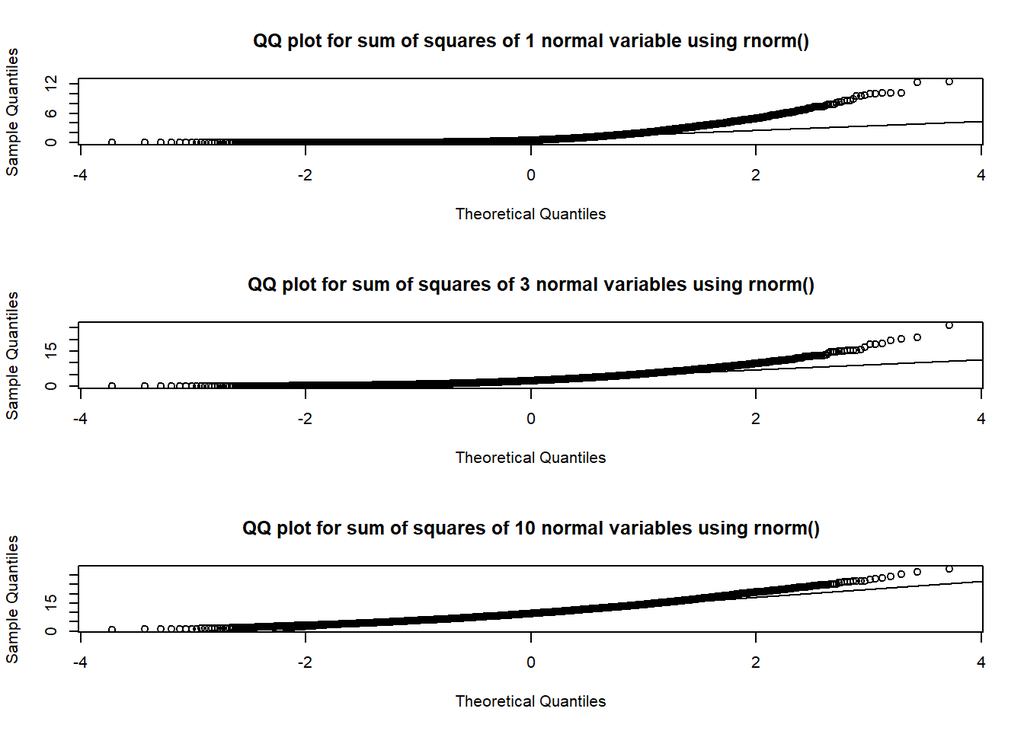

```r
sample_size <- 5000

#generate 5000 samples of sum of squares of 1, 3, and 10 variables using rnorm
sum.sq_1 <- replicate(sample_size, sum(rnorm(1)^2))
sum.sq_3 <- replicate(sample_size, sum(rnorm(3)^2))
sum.sq_10 <- replicate(sample_size, sum(rnorm(10)^2))

#generate chi-square variables using rchisq
chi.sq_1 <- rchisq(sample_size, df = 1)
chi.sq_3 <- rchisq(sample_size, df=3)
chi.sq_10 <- rchisq(sample_size, df=10)

#compare using QQplot

par(mfrow = c(3, 1))
qqnorm(sum.sq_1, main = "QQ plot for sum of squares of 1 normal variable using rnorm()")
qqline(sum.sq_1)

qqnorm(sum.sq_3, main = "QQ plot for sum of squares of 3 normal variables using rnorm()")
qqline(sum.sq_3)

qqnorm(sum.sq_10, main = "QQ plot for sum of squares of 10 normal variables using rnorm()")
qqline(sum.sq_10)
```

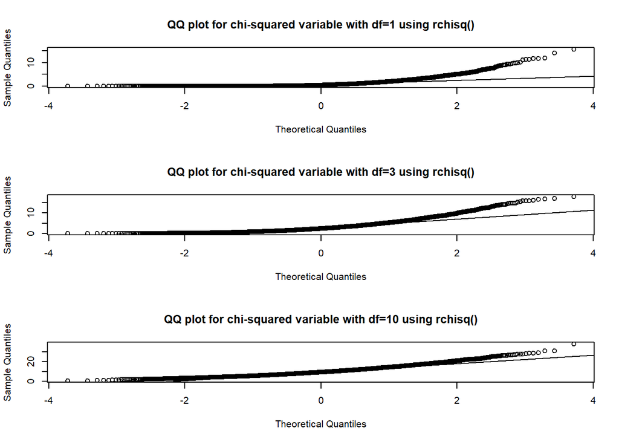

```r
qqnorm(chi.sq_1, main = "QQ plot for chi-squared variable with df=1 using rchisq()")
qqline(chi.sq_1)

qqnorm(chi.sq_3, main = "QQ plot for chi-squared variable with df=3 using rchisq()")
qqline(chi.sq_3)

qqnorm(chi.sq_10, main = "QQ plot for chi-squared variable with df=10 using rchisq()")
qqline(chi.sq_10)
```

### 12d. Calculate “by hand” the rest of the expected values in remission/sex contingency table example (see Notes part 2, page 6).

```r
table_ex <- table(pData(ALL)$sex,pData(ALL)$remission)

#calcualte row and column
row_totals <- apply(table_ex, 1, sum)
col_totals <- apply(table_ex, 2, sum)

grand_total <- sum(table_ex)

example_table <- outer(row_totals, col_totals)/grand_total

cbind(observed=table_ex, expected=round(example_table,2))
```

```
##   CR REF    CR   REF
## F 27   7 29.49  4.51
## M 71   8 68.51 10.49
```